# Assignment 04 - HPC and ML 2

## Due Date

April 5, 2024 by 11:59pm.

## HPC

1. Make sure your code is nice! Rewrite the following R functions to make them faster. It is OK (and recommended) to take a look at Stackoverflow.

```r
# Total row sums
fun1 <- function(mat) {
  n <- nrow(mat)
  ans <- double(n)
  for (i in 1:n) {
    ans[i] <- sum(mat[i, ])
  }
  ans
}

fun1alt <- function(mat) {
  # YOUR CODE HERE
  rowSums(mat)
}

# Cumulative sum by row
fun2 <- function(mat) {
  n <- nrow(mat)
  k <- ncol(mat)
  ans <- mat
  for (i in 1:n) {
    for (j in 2:k) {
      ans[i,j] <- mat[i, j] + ans[i, j - 1]
    }
  }
  ans
}

fun2alt <- function(mat) {
  # YOUR CODE HERE
  t(apply(mat, 1, cumsum))
}


# Use the data with this code
set.seed(2315)
dat <- matrix(rnorm(200 * 100), nrow = 200)

# Test for the first
microbenchmark::microbenchmark(
  fun1(dat),
  fun1alt(dat), unit = "relative", check = "equivalent"
)

# Test for the second
microbenchmark::microbenchmark(
  fun2(dat),
  fun2alt(dat), unit = "relative", check = "equivalent"
)
```

The last argument, check = “equivalent”, is included to make sure that the functions return the same result.

2. Make things run faster with parallel computing. The following function allows simulating Pi:

```r
sim_pi <- function(n = 1000, i = NULL) {
  p <- matrix(runif(n*2), ncol = 2)
  mean(rowSums(p^2) < 1) * 4
}

# Here is an example of the run
set.seed(156)
sim_pi(1000) # 3.132
```

In order to get accurate estimates, we can run this function multiple times, with the following code:

```r
# This runs the simulation a 4,000 times, each with 10,000 points
set.seed(1231)
system.time({
  ans <- unlist(lapply(1:4000, sim_pi, n = 10000))
  print(mean(ans))
})
```

Rewrite the previous code using `parLapply()` to make it run faster. Make sure you set the seed using `clusterSetRNGStream()`:

```r
# YOUR CODE HERE
ncpus <- 4
cl <- makePSOCKcluster(ncpus)
clusterSetRNGStream(cl, 123)

system.time({
  # YOUR CODE HERE
  ans <- unlist(parLapply(cl, rep(10000, 4000), sim_pi))
  print(mean(ans))
  # YOUR CODE HERE
  stopCluster(cl)
})
```

## Machine Learning

For this part we will use the `hitters` dataset, which consists of data for 332 major league baseball players. The data are [here](https://github.com/JSC370/JSC370-2024/tree/main/data/hitters). The main goal is to predict players’ salaries (variable `Salary`) based on the features in the data. To do so you will replicate many of the concepts in lab 10 (trees, bagging, random forest, boosting and xgboost). Please split the data into training and testing sets (70-30) and use the same sets for all questions.

```r
library(tidyverse)
library(rpart)
library(rpart.plot)
library(randomForest)
library(gbm)
library(xgboost)
library(caret)
```

```r
hitters <- read.csv("hitters.csv", stringsAsFactors = TRUE)
hitters <- na.omit(hitters)
n <- nrow(hitters)
```

```r
train_size<-sample(1:n, size = n * 0.7)
train <- hitters[train_size,]
test <- hitters[-train_size,]
```

### 1. Fit a regression tree to predict `Salary`, and appropriately prune it based on the optimal complexity parameter. Summarize.

```r
treefit<-rpart(Salary~ ., method = 'anova', control = list(cp=0), data = train)
```

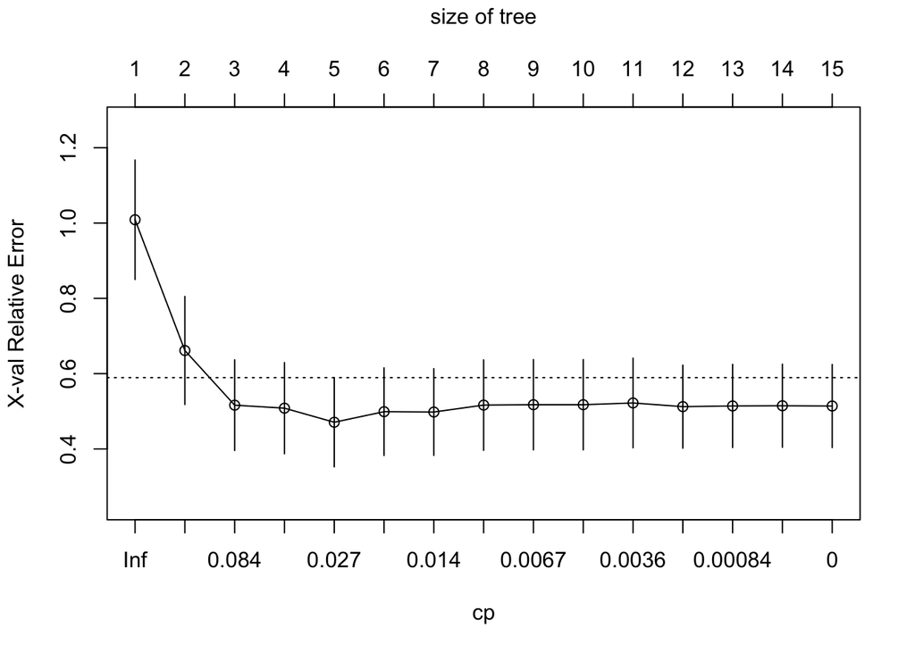

```r
plotcp(treefit)
```

```r
treefit$cptable
```

```
##              CP nsplit rel error    xerror      xstd
## 1  0.3595386276      0 1.0000000 1.0087807 0.1586279
## 2  0.1523475977      1 0.6404614 0.6614893 0.1434294
## 3  0.0465183474      2 0.4881138 0.5163155 0.1204327
## 4  0.0357655749      3 0.4415954 0.5083331 0.1210310
## 5  0.0204531868      4 0.4058299 0.4709083 0.1184468
## 6  0.0190276584      5 0.3853767 0.4990055 0.1163157
## 7  0.0104522260      6 0.3663490 0.4980863 0.1151961
## 8  0.0072969080      7 0.3558968 0.5165087 0.1201007
## 9  0.0061285537      8 0.3485999 0.5175039 0.1199153
## 10 0.0057686965      9 0.3424713 0.5175039 0.1199153
## 11 0.0022232950     10 0.3367026 0.5221602 0.1190069
## 12 0.0014304266     11 0.3344793 0.5123884 0.1102148
## 13 0.0004904803     12 0.3330489 0.5142524 0.1103920
## 14 0.0001369620     13 0.3325584 0.5147638 0.1104019
## 15 0.0000000000     14 0.3324215 0.5140600 0.1102970
```

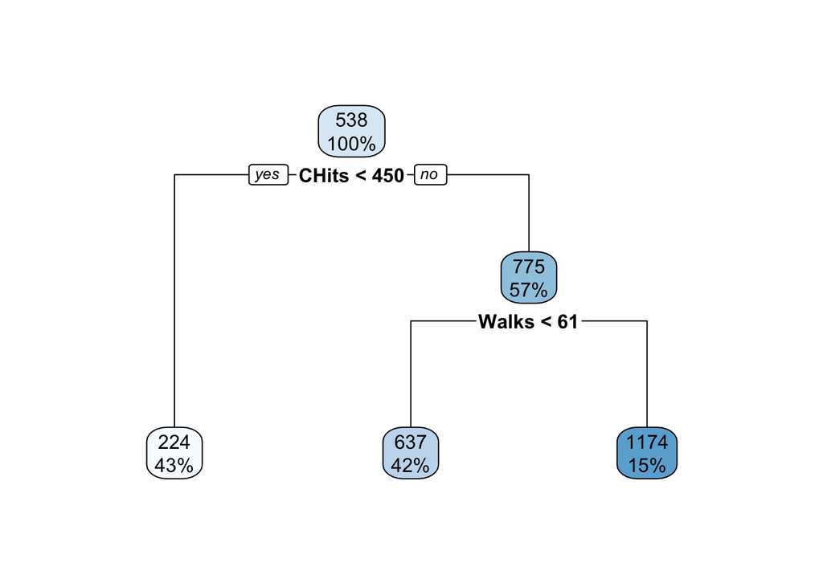

```r
optimalcp<-0.149
treepruned<-prune(treefit, cp=optimalcp)

rpart.plot(treepruned)
```

```r
summary(treepruned)
```

```
## Call:
## rpart(formula = Salary ~ ., data = train, method = "anova", control = list(cp = 0))
##   n= 184
##
##          CP nsplit rel error    xerror      xstd
## 1 0.3595386      0 1.0000000 1.0087807 0.1586279
## 2 0.1523476      1 0.6404614 0.6614893 0.1434294
## 3 0.1490000      2 0.4881138 0.5163155 0.1204327
##
## Variable importance
##   CHits  CAtBat   CRuns    CRBI  CWalks   Years   Walks    Runs   HmRun PutOuts
##      16      16      15      14      14      11       7       2       1       1
##     RBI  CHmRun
##       1       1
##
## Node number 1: 184 observations,    complexity param=0.3595386
##   mean=538.3806, MSE=206883.6
##   left son=2 (79 obs) right son=3 (105 obs)
##   Primary splits:
##       CHits  < 450    to the left,  improve=0.3595386, (0 missing)
##       CRuns  < 215    to the left,  improve=0.3515938, (0 missing)
##       CAtBat < 1762.5 to the left,  improve=0.3461206, (0 missing)
##       CRBI   < 300.5  to the left,  improve=0.3454553, (0 missing)
##       CWalks < 131    to the left,  improve=0.2989196, (0 missing)
##   Surrogate splits:
##       CAtBat < 1551   to the left,  agree=0.984, adj=0.962, (0 split)
##       CRuns  < 205.5  to the left,  agree=0.973, adj=0.937, (0 split)
##       CRBI   < 161.5  to the left,  agree=0.951, adj=0.886, (0 split)
##       CWalks < 131    to the left,  agree=0.935, adj=0.848, (0 split)
##       Years  < 4.5    to the left,  agree=0.864, adj=0.684, (0 split)
##
## Node number 2: 79 observations
##   mean=223.9557, MSE=63006.53
##
## Node number 3: 105 observations,    complexity param=0.1523476
##   mean=774.9479, MSE=184787.3
##   left son=6 (78 obs) right son=7 (27 obs)
##   Primary splits:
##       Walks < 61     to the left,  improve=0.2988947, (0 missing)
##       RBI   < 103    to the left,  improve=0.2773166, (0 missing)
##       Runs  < 65.5   to the left,  improve=0.2355495, (0 missing)
##       AtBat < 426.5  to the left,  improve=0.2352500, (0 missing)
##       Hits  < 114    to the left,  improve=0.2159139, (0 missing)
##   Surrogate splits:
##       Runs    < 77.5   to the left,  agree=0.829, adj=0.333, (0 split)
##       HmRun   < 23.5   to the left,  agree=0.790, adj=0.185, (0 split)
##       RBI     < 84.5   to the left,  agree=0.781, adj=0.148, (0 split)
##       PutOuts < 744    to the left,  agree=0.781, adj=0.148, (0 split)
##       CHmRun  < 250    to the left,  agree=0.771, adj=0.111, (0 split)
##
## Node number 6: 78 observations
##   mean=636.6774, MSE=88582.05
##
## Node number 7: 27 observations
##   mean=1174.396, MSE=247922.6
```

### 2. Predict `Salary` using bagging, construct a variable importance plot.

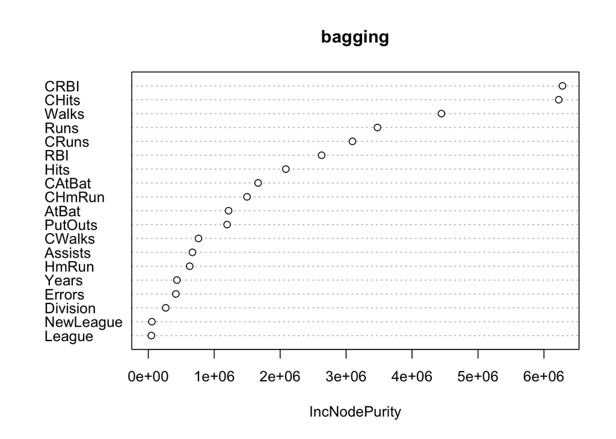

```r
n_features <- dim(train)[2] - 1

bagging <- randomForest(Salary ~ . ,
                        data = train,
                        mtry = n_features,
                        na.action = na.omit)
varImpPlot(bagging)
```

```r
importance(bagging)
```

```
##           IncNodePurity
## AtBat        1216988.04
## Hits         2085714.93
## HmRun         627785.00
## Runs         3475207.30
## RBI          2628649.08
## Walks        4445818.29
## Years         433674.97
## CAtBat       1664839.17
## CHits        6224909.54
## CHmRun       1496674.35
## CRuns        3095782.13
## CRBI         6280974.84
## CWalks        760924.57
## League         45958.55
## Division      264715.71
## PutOuts      1194980.33
## Assists       669375.26
## Errors        418121.29
## NewLeague      54460.47
```

### 3. Repeat 2. using random forest.

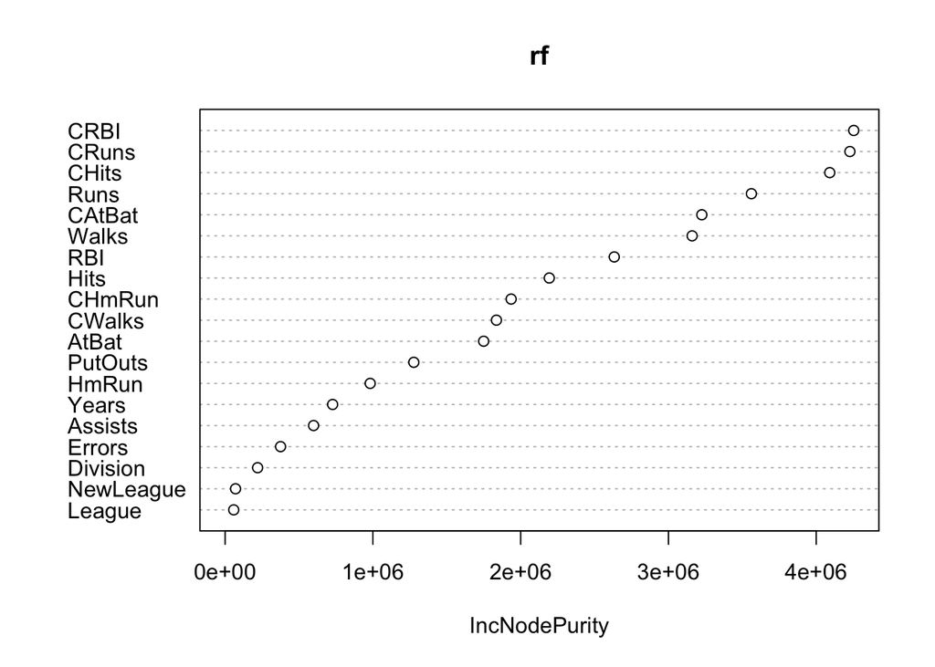

```r
rf <- randomForest(Salary ~ . ,
                   data = train,
                   na.action = na.omit)
varImpPlot(rf)
```

```r
importance(rf)
```

```
##           IncNodePurity
## AtBat        1749562.38
## Hits         2193452.98
## HmRun         981690.69
## Runs         3561329.54
## RBI          2633213.44
## Walks        3160209.32
## Years         727551.83
## CAtBat       3225682.95
## CHits        4091396.12
## CHmRun       1935474.03
## CRuns        4227713.74
## CRBI         4253837.65
## CWalks       1835919.17
## League         58282.29
## Division      220006.29
## PutOuts      1276775.80
## Assists       598700.19
## Errors        375383.47
## NewLeague      70608.52
```

### 4. Perform boosting with 1,000 trees for a range of values of the shrinkage parameter $\lambda$. Produce a plot with different shrinkage values on the x-axis and corresponding training set MSE on the y-axis. Construct a variable importance plot.

```r
lambdas <- c(0.01,0.1,0.3)
mses <- numeric(3)
names(mses) <- lambdas

for (lambda in lambdas) {
  boost <- gbm(
    Salary ~ .,
    data = train,
    distribution = "gaussian",
    n.trees = 1000,
    shrinkage = lambda,
    cv.folds = 5
  )
  pred <- predict(boost, train, n.trees = 1000, type = "response")
  mses[as.character(lambda)] <- mean((train$Salary - pred)^2)
}
```

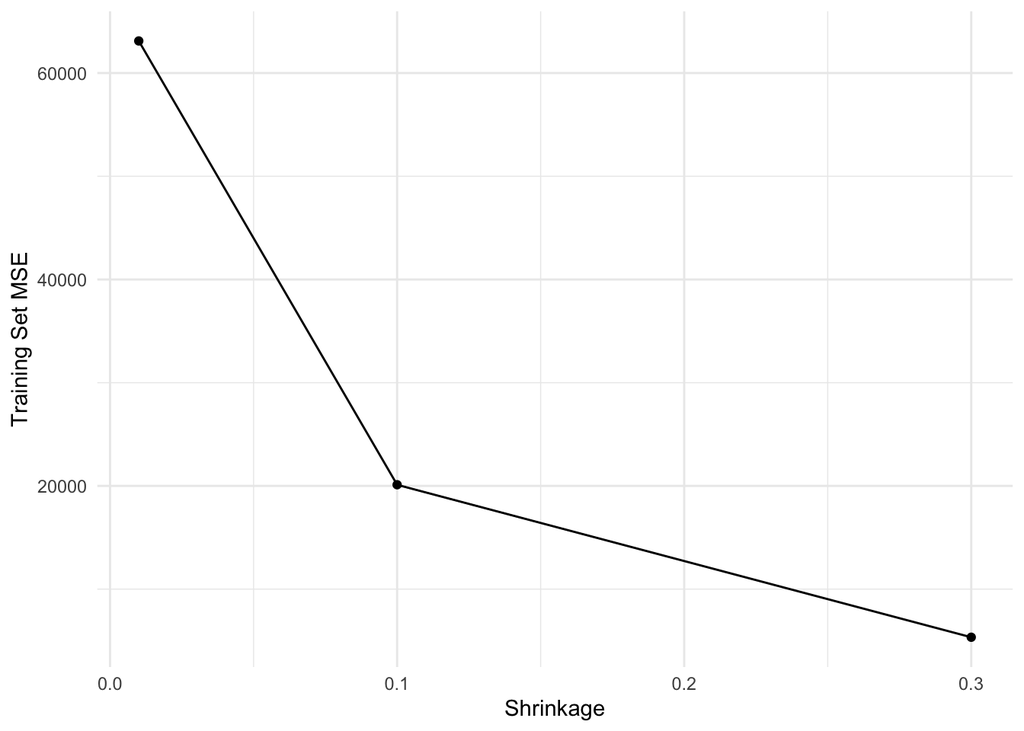

```r
mse_df <- data.frame(shrinkage = lambdas, mse = mses)
ggplot(mse_df, aes(x = shrinkage, y = mse)) +
  geom_line() +
  geom_point() +
  theme_minimal() +
  labs(x = "Shrinkage", y = "Training Set MSE")
```

```r
summary_gbm <- summary.gbm(boost)
```

[figure not shown]

```r
summary_gbm
```

```
##                 var     rel.inf
## PutOuts     PutOuts 10.16769557
## Walks         Walks  9.34839869
## AtBat         AtBat  8.63904327
## CHmRun       CHmRun  7.68186586
## CHits         CHits  7.04235143
## Hits           Hits  6.98192109
## HmRun         HmRun  6.22802107
## RBI             RBI  6.17604426
## CRuns         CRuns  5.68747630
## Years         Years  5.44617517
## Assists     Assists  5.40134003
## Runs           Runs  5.14199026
## CWalks       CWalks  4.84149373
## CRBI           CRBI  4.63843415
## CAtBat       CAtBat  3.19787721
## Errors       Errors  2.19942732
## Division   Division  0.93558684
## League       League  0.23157458
## NewLeague NewLeague  0.01328316
```

5. Repeat 4. using XGBoost (set up as a grid search on eta, can also grid search on other parameters).

```r
grid <- expand.grid(eta = c(0.01,0.1,0.3),
                    nrounds = (1:10)*50,
                    max_depth = c(1, 3, 5, 7),
                    gamma = 0,
                    colsample_bytree = 0.6,
                    subsample = 1,
                    min_child_weight = 1)

cv_control <- trainControl(method = "cv", number = 10, search = "grid")

xgb <- caret::train(
  Salary ~ .,
  data = train,
  method = "xgbTree",
  trControl = cv_control,
  tuneGrid = grid,
  metric = "RMSE",
  verbosity = 0
)

print(xgb)
```

[output not shown]

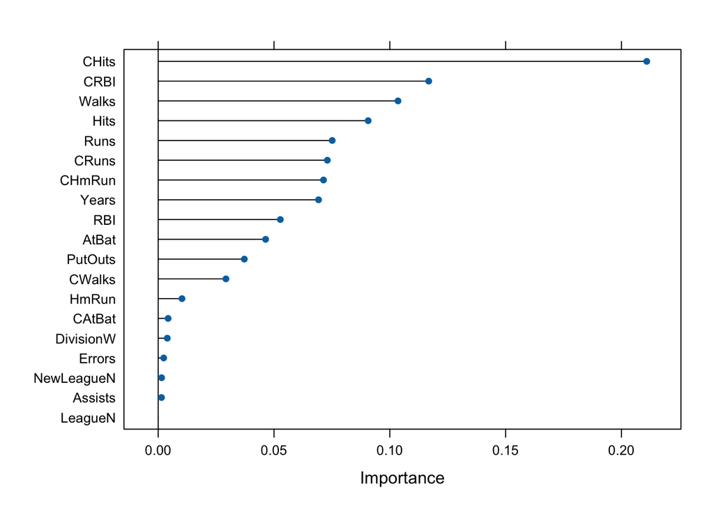

```r
varimp <- varImp(xgb, scale = FALSE)
plot(varimp)
```

### 6. Calculate the test MSE for each method and compare. Which approach has the best performance?

```r
pred_treepruned <- predict(treepruned, test)
mse_treepruned <- mean((test$Salary - pred_treepruned)^2)

pred_bagging <- predict(bagging, test)
mse_bagging <- mean((test$Salary - pred_bagging)^2)

pred_rf <- predict(rf, test)
mse_rf <- mean((test$Salary - pred_rf)^2)

pred_boost <- predict(boost, test, n.trees = 1000, type = "response")
mse_boost <- mean((test$Salary - pred_boost)^2)

pred_xgb <- predict(xgb, newdata = test)
mse_xgb <- mean((test$Salary - pred_xgb)^2)

mse_comparison <- data.frame(
  Method = c("Regression Tree", "Bagging", "Random Forest", "Boosting", "XGBoost"),
  MSE = c(mse_treepruned, mse_bagging, mse_rf, mse_boost, mse_xgb)
)

mse_comparison
```

```
##            Method       MSE
## 1 Regression Tree 107628.66
## 2         Bagging  64098.81
## 3   Random Forest  61269.87
## 4        Boosting  88415.55
## 5         XGBoost  56363.88
```

XGBoost has the best performance with lowest test MSE.

7. Compare the variable importance across 2 through 4 (bagging, rf, boosting, XGBoost).

Bagging: The top three features are CRBI, CHits, and Walks. Bagging seems to give more importance to the cumulative statistics.

Random Forest: The top three features are CHits, CRBI, and CRuns, which shows that similar to bagging, rf also emphasizes career statistics but also includes career runs, which points to the player’s ability to score.